# Tugas Kelompok

**KELOMPOK 11:**

**Asfiah Adiba - G1401211004**

**Arfiah Kania Sektiaruni - G1401211023**

**Adisti Suci Rahmah - G1401211027**

**Dindana Fitriani- G1401211034**

**Anis Sulistiyowati- G1401211084**

# Packages

```r
library(ggplot2)
library(tsibble)
library(tseries)
library(MASS)
library(forecast)
library(TSA)
library(TTR)
library(aTSA)
library(graphics)
```

# Impor Data

```r
datalat8 <- rio::import("https://raw.githubusercontent.com/afhkaniase/praktikum-mpdw/main/Kelompok%2011/Data%20Temperatur%20Portugal%202023.csv")
str(datalat8)
```

```
## 'data.frame':    212 obs. of  2 variables:
##  $ Periode    : int  1 2 3 4 5 6 7 8 9 10 ...
##  $ Temperature: num  15.9 11.1 10.2 9.9 9.9 11 14.8 16.2 15.4 14.4 ...
```

```r
head(datalat8)
```

```
##   Periode Temperature
## 1       1        15.9
## 2       2        11.1
## 3       3        10.2
## 4       4         9.9
## 5       5         9.9
## 6       6        11.0
```

## Mengubah data agar terbaca sebagai data deret waktu dengan fungsi `ts()` .

```r
datalat8.ts <- ts(datalat8$Temperature)
datalat8.ts
```

```
## Time Series:
## Start = 1
## End = 212
## Frequency = 1
##   [1] 15.9 11.1 10.2  9.9  9.9 11.0 14.8 16.2 15.4 14.4 13.9 11.5 11.6 10.5 11.6
##  [16] 12.9 12.8  9.4  9.9 14.0 13.7 10.2  8.2  8.3  7.6  8.8  9.3  8.3  7.5  7.5
##  [31]  8.5  8.3  8.3 10.0 11.6 11.7 11.0  9.7  9.5 12.1 10.4  9.6 11.4 12.3 12.3
##  [46] 14.4 13.7 13.9 14.4 13.9 13.8 13.5 12.5  9.8  7.9  8.8 10.6  9.9  8.5  8.1
##  [61]  8.2  9.5 10.5 11.7 13.3 14.2 15.8 16.5 15.4 16.9 15.2 15.2 14.4 14.3 13.2
##  [76] 14.7 13.7 14.5 14.7 14.3 13.9 14.1 16.0 14.2 15.6 15.7 17.4 17.0 16.8 17.0
##  [91] 15.8 16.3 15.1 17.7 19.0 19.0 17.5 17.1 18.2 16.1 16.7 15.3 13.2 14.7 18.1
## [106] 20.2 22.9 21.4 19.2 16.2 14.4 15.8 16.7 18.7 18.6 20.2 23.7 21.6 18.8 19.0
## [121] 21.0 21.7 20.4 18.7 18.2 18.9 19.2 19.4 19.5 17.4 17.6 16.7 17.7 18.1 17.4
## [136] 19.8 21.6 20.0 19.5 19.3 18.2 18.1 19.2 20.2 21.8 17.7 18.8 18.5 18.2 19.0
## [151] 18.9 19.4 20.0 20.1 20.6 21.6 22.0 21.4 20.0 20.0 20.9 20.1 20.6 20.0 21.0
## [166] 24.0 24.4 22.1 21.3 20.5 20.4 19.9 21.7 26.0 27.4 25.1 24.7 23.7 23.6 21.5
## [181] 21.9 23.7 24.6 22.2 21.5 21.4 21.5 21.1 21.9 21.5 23.3 22.5 22.8 23.9 22.7
## [196] 21.7 20.3 22.0 22.2 21.8 21.3 21.2 21.6 20.9 21.4 20.6 22.4 20.5 22.2 23.3
## [211] 22.6 21.9
```

## Eksplorasi Data

Sebelum masuk dalam tahap pemodelan, dilakukan eksplorasi data dengan plot deret waktu untuk melihat pola data.

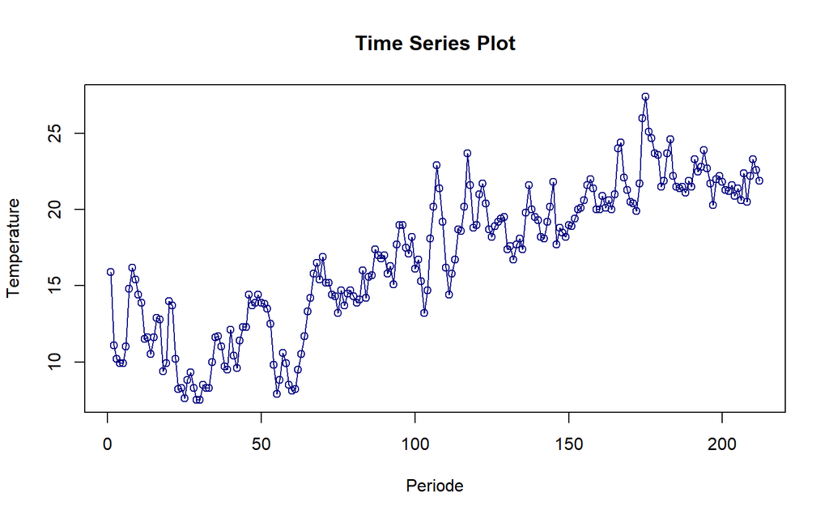

```r
#--PLOT TIME SERIES--#
plot(datalat8.ts,
     col = "navyblue",
     lwd = 1,
     type = "o",
     xlab = "Periode",
     ylab = "Temperature",
     main = "Time Series Plot")
```

Berdasarkan plot data deret waktu penuh di atas, terlihat bahwa data memiliki pola trend sehingga pembagian data latih dan data uji ditetapkan dengan proporsi 83%:17%.

# Plot Data Latih

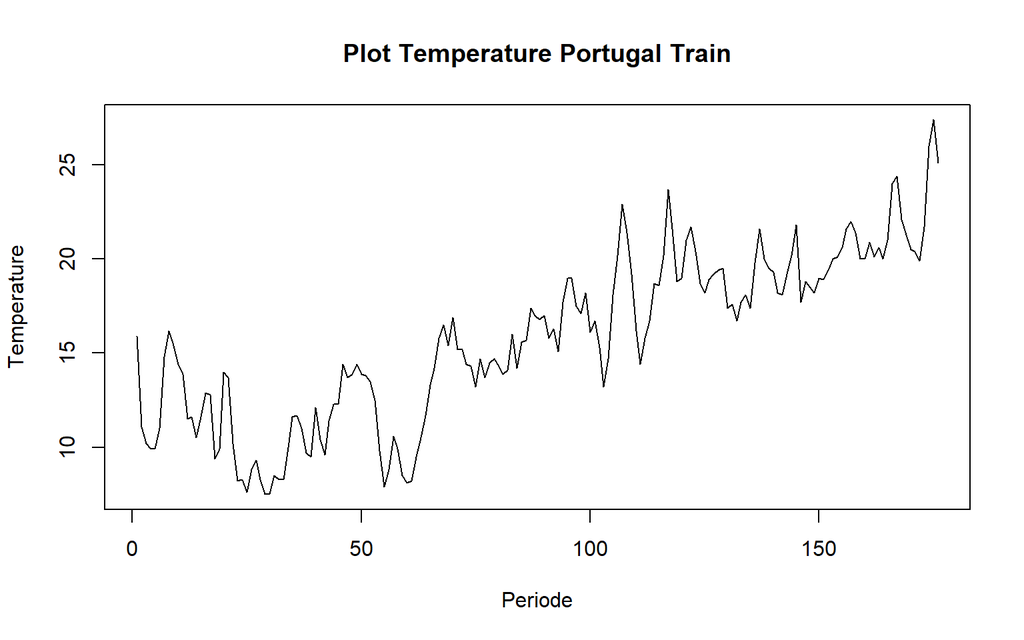

```r
ma2.train <- datalat8$Temperature[1:176]
train.ts<-ts(ma2.train)
plot.ts(train.ts, lty=1, xlab="Periode", ylab="Temperature", main="Plot Temperature Portugal Train")
```

Berdasarkan plot data deret waktu pada data latih, terlihat bahwa data cenderung memiliki trend yang naik. Hal ini mengindikasikan bahwa data tidak stasioner dalam rataan.

# Plot Data Uji

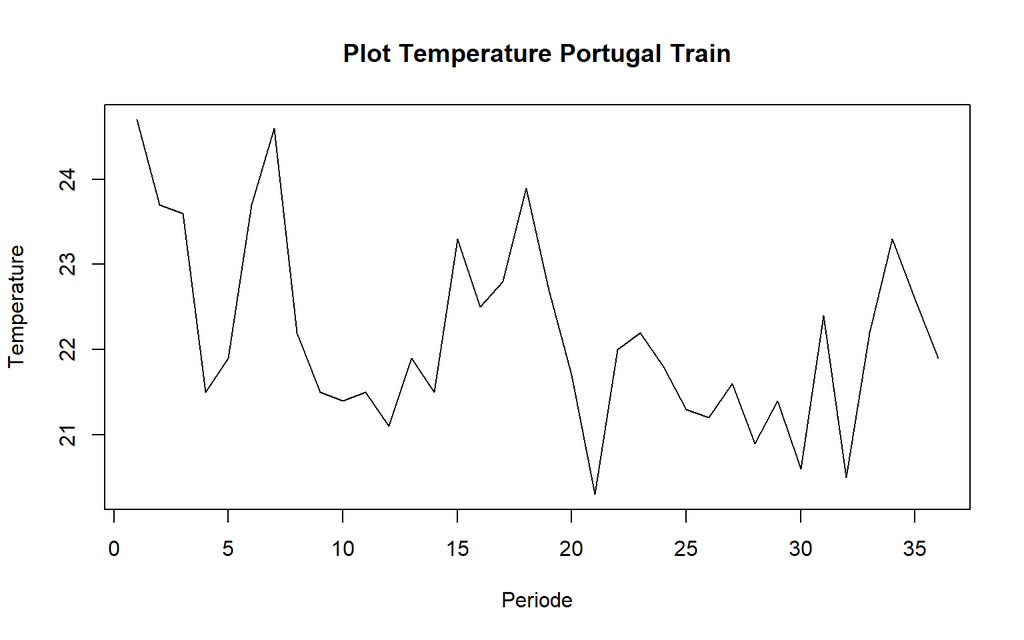

```r
ma2.test <- datalat8$Temperature[177:212]
test.ts<-ts(ma2.test)
plot.ts(test.ts, lty=1, xlab="Periode", ylab="Temperature", main="Plot Temperature Portugal Train")
```

Berdasarkan plot data deret waktu pada data uji di atas, terlihat pola data musiman yang tidak stasioner dalam rataan dan ragam. Data tidak stasioner dalam rataan karena tidak menyebar/bergerak di sekitar nilai tengahnya (0) dan dikatakan tidak stasioner dalam ragam karena memiliki lebar pita yang tidak sama. Selain dengan plot data deret waktu, akan dilakukan pengecekan stasioneritas data dengan plot ACF dan uji ADF.

# Uji Kestasioneran Data

## Plot ACF

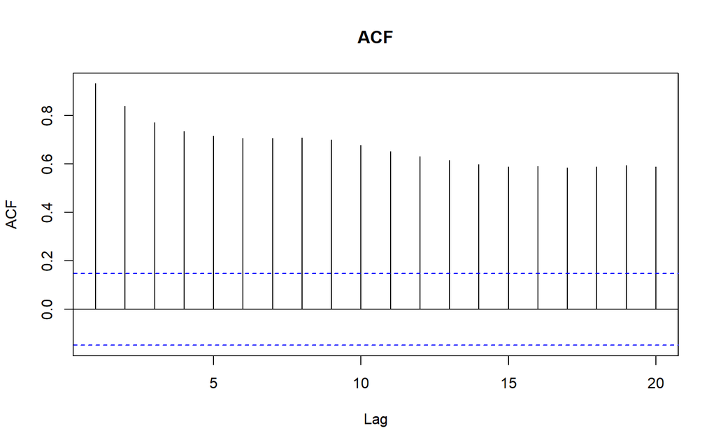

```r
acf(ma2.train, main="ACF", lag.max=20)
```

Berdasarkan plot ACF di atas, pada data tersebut menurun secara perlahan (*tails off slowly*) yang menandakan data tidak stasioner dalam rataan.

## Uji ADF

```r
tseries::adf.test(ma2.train)
```

```
##
##  Augmented Dickey-Fuller Test
##
## data:  ma2.train
## Dickey-Fuller = -3.5864, Lag order = 5, p-value = 0.03645
## alternative hypothesis: stationary
```

$H_0$ : Data tidak stasioner dalam rataan

$H_1$ : Data stasioner dalam rataan

Berdasarkan uji ADF tersebut, didapat *p-value* sebesar 0.03645 yang lebih kecil dari taraf nyata 5% sehingga tolak $H_0$ dan menandakan bahwa data stasioner dalam rataan. Hal ini tidak sesuai dengan hasil eksplorasi menggunakan plot time series dan plot ACF. Hal ini tidak sesuai dengan hasil eksplorasi menggunakan plot time series dan plot ACF. Setelah dicoba-coba dengan mengganti nilai k (dinaikkan nilai k nya) hasil *p-value* tetap lebih kecil dari taraf nyata 5%.

## Plot Box-Cox

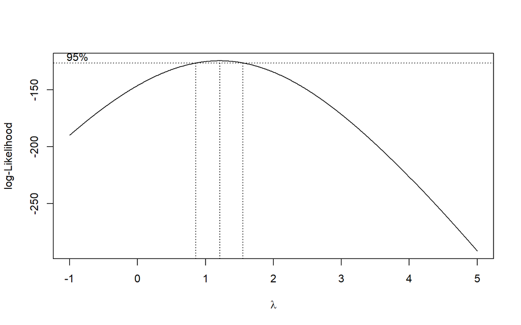

```r
index <- seq(1:176)
bc = boxcox(train.ts~index, lambda = seq(-1,5,by=0.01))
```

```r
#Nilai Rounded Lambda
lambda <- bc$x[which.max(bc$y)]
lambda
```

```
## [1] 1.21
```

```r
#SK
bc$x[bc$y > max(bc$y) - 1/2 * qchisq(.95,1)]
```

```
##  [1] 0.86 0.87 0.88 0.89 0.90 0.91 0.92 0.93 0.94 0.95 0.96 0.97 0.98 0.99 1.00
## [16] 1.01 1.02 1.03 1.04 1.05 1.06 1.07 1.08 1.09 1.10 1.11 1.12 1.13 1.14 1.15
## [31] 1.16 1.17 1.18 1.19 1.20 1.21 1.22 1.23 1.24 1.25 1.26 1.27 1.28 1.29 1.30
## [46] 1.31 1.32 1.33 1.34 1.35 1.36 1.37 1.38 1.39 1.40 1.41 1.42 1.43 1.44 1.45
## [61] 1.46 1.47 1.48 1.49 1.50 1.51 1.52 1.53 1.54 1.55
```

Plot Boxcox menunjukkan nilai *rounded value* ($\lambda$) optimum sebesar **1.21** dan pada selang kepercayaan 95% nilai memiliki batas bawah **0.86** dan batas atas **1.55**. Selang tersebut memuat nilai satu sehingga dapat dikatakan bahwa data yang digunakan stasioner dalam ragam.

## Penanganan Ketidakstasioneran Data

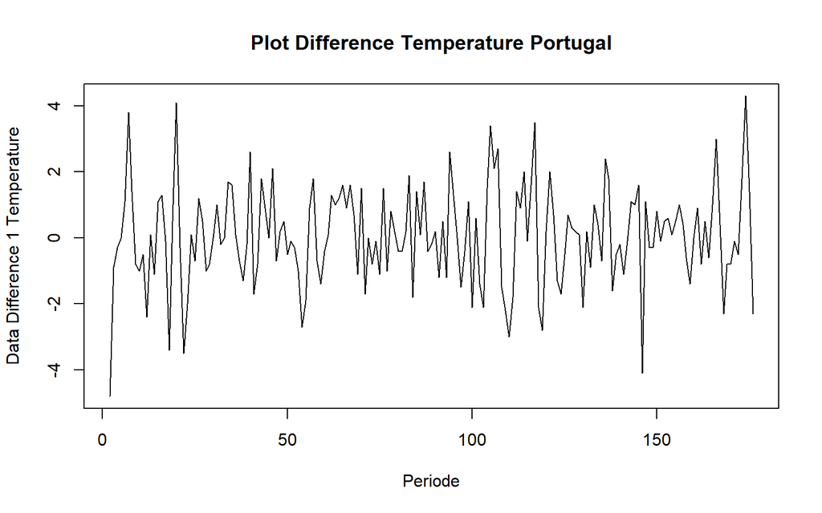

```r
train.diff1<-diff(train.ts,differences = 1)
plot.ts(train.diff1, lty=1, xlab="Periode", ylab="Data Difference 1 Temperature", main="Plot Difference Temperature Portugal")
```

Berdasarkan plot data deret waktu, terlihat bahwa data sudah stasioner dalam rataan ditandai dengan data bergerak pada nilai tengah tertentu (tidak terdapat trend ataupun musiman pada data).

## Plot ACF

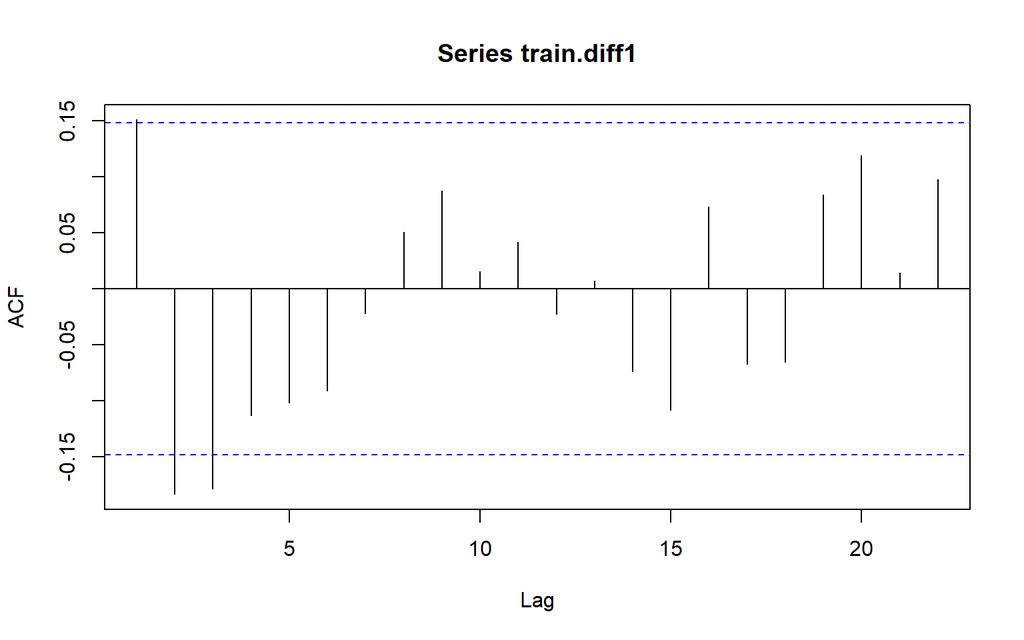

```r
acf(train.diff1)
```

Berdasarkan plot tersebut, terlihat bahwa plot ACF *cuts off* pada lag ke 3. Hal ini menandakan data sudah stasioner dalam rataan dan ketidakstasioneran data telah berhasil tertangani.

## Uji ADF

```r
tseries::adf.test(train.diff1)
```

```
##
##  Augmented Dickey-Fuller Test
##
## data:  train.diff1
## Dickey-Fuller = -7.8965, Lag order = 5, p-value = 0.01
## alternative hypothesis: stationary
```

$H_0$ : Data tidak stasioner dalam rataan

$H_1$ : Data stasioner dalam rataan

Berdasarkan uji ADF tersebut, didapat *p-value* sebesar 0.01 yang lebih kecil dari taraf nyata 5% sehingga tolak $H_0$ atau data stasioner dalam rataan. Hal ini sesuai dengan hasil eksplorasi menggunakan plot time series dan plot ACF, sehingga dalam hal ini ketidakstasioneran data sudah berhasil ditangani dan dapat dilanjutkan ke pemodelan

# Identifikasi Model

## Plot ACF

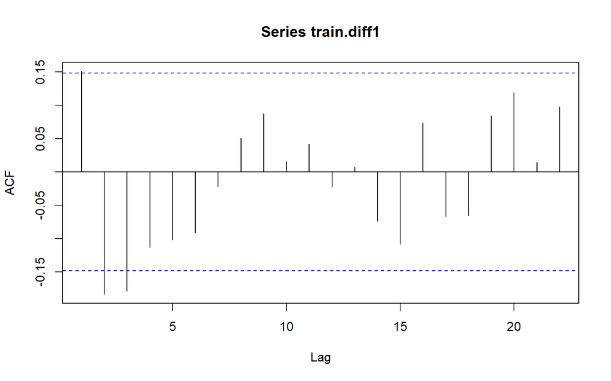

```r
acf(train.diff1)
```

Berdasarkan plot tersebut, terlihat bahwa plot ACF cenderung *cuts off* pada lag ke 3, sehingga jika plot PACF dianggap *tails of*, maka model tentatifnya adalah ARIMA(0,1,3).

## Plot PACF

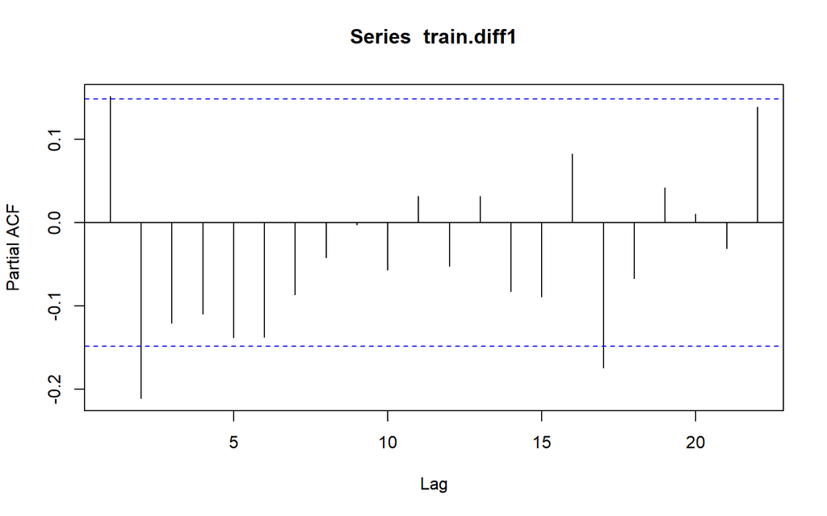

```r
pacf(train.diff1)
```

Berdasarkan plot tersebut, terlihat bahwa plot PACF cenderung *cuts off* pada lag ke 2, sehingga jika plot ACF dianggap *tails of*, maka model tentatifnya adalah ARIMA(2,1,0).

Jika baik plot ACF maupun plot PACF keduanya dianggap tails of, maka model yang terbentuk adalah ARIMA(2,1,3)

## Plot EACF

```r
eacf(train.diff1)
```

```
## AR/MA
##   0 1 2 3 4 5 6 7 8 9 10 11 12 13
## 0 o x x o o o o o o o o  o  o  o
## 1 x x o o o o o o o o o  o  o  o
## 2 x o x o o o o o o o o  o  o  o
## 3 x o o o o o o o o o o  o  o  o
## 4 x o o o o o o o o o o  o  o  o
## 5 x o x x o o o o o o o  o  o  o
## 6 x o o x o o o o o o o  o  o  o
## 7 x x o x o o o o o o o  o  o  o
```

Identifikasi model menggunakan plot EACF dilakukan dengan melihat ujung segitiga pada pola segitiga nol. Dalam hal ini model tentatif yang terbentuk adalah ARIMA(0,1,3), ARIMA(1,1,2), ARIMA(2,1,1), dan ARIMA(3,1,1)

# Pendugaan Parameter Model Tentatif

## ARIMA(0,1,3)

```r
model1.da=Arima(train.diff1, order=c(0,1,3),method="ML")
summary(model1.da) #AIC=638.77
```

```
## Series: train.diff1
## ARIMA(0,1,3)
##
## Coefficients:
##           ma1      ma2     ma3
##       -0.8738  -0.3306  0.2044
## s.e.   0.1016   0.0902  0.1134
##
## sigma^2 = 2.167:  log likelihood = -315.39
## AIC=638.77   AICc=639.01   BIC=651.41
##
## Training set error measures:
##                     ME   RMSE      MAE MPE MAPE      MASE       ACF1
## Training set 0.1797442 1.4552 1.147557 Inf  Inf 0.7498121 0.05934759
```

```r
lmtest::coeftest(model1.da) #terdapat parameter yang tidak signifikan
```

```
##
## z test of coefficients:
##
##      Estimate Std. Error z value  Pr(>|z|)
## ma1 -0.873775   0.101607 -8.5996 < 2.2e-16 ***
## ma2 -0.330632   0.090183 -3.6662 0.0002461 ***
## ma3  0.204408   0.113388  1.8027 0.0714299 .
## ---
## Signif. codes:  0 '***' 0.001 '**' 0.01 '*' 0.05 '.' 0.1 ' ' 1
```